# tarea progra

# Ejercicios

*ALUMNO:ALEXANDER RENATO ZAMORA TELLO*

*CODIGO :17160048*

## Parte 1

Cargar las variables almacenadas en el siguiente archivo [Rdata](https://goo.gl/uDzU8v)

```r
load("datosprogra.RData")
```

**1. Calcula los valores numéricos aproximados de**

1. $\frac{0.3 \cdot 0.15}{0.3 \cdot 0.15 + 0.2 \cdot 0.8 + 0.5 \cdot 0.12}$

```r
a <- (0.3*0.15)/((0.3*0.15) + (0.2*0.8) + (0.5*0.12))
round(a, 2)
```

```
## [1] 0.17
```

2. $\frac{5^6}{6!} e^{-5}$

```r
b <- ((5^6)*(2.718281^-5))/(1*2*3*4*5*6)
round(b,2)
```

```
## [1] 0.15
```

```r
x <- matrix(c(20,7), nrow = 2 , ncol = 1)
c <- x*(0.4^7)*(0.6^13)
round(c,4)
```

```
##      [,1]
## [1,]    0
## [2,]    0
```

**2. Realizar la siguiente suma**

```r
a <- 1:100
sum(a)
```

```
## [1] 5050
```

```r
round(a,2)
```

```
##   [1]   1   2   3   4   5   6   7   8   9  10  11  12  13  14  15  16  17  18
##  [19]  19  20  21  22  23  24  25  26  27  28  29  30  31  32  33  34  35  36
##  [37]  37  38  39  40  41  42  43  44  45  46  47  48  49  50  51  52  53  54
##  [55]  55  56  57  58  59  60  61  62  63  64  65  66  67  68  69  70  71  72
##  [73]  73  74  75  76  77  78  79  80  81  82  83  84  85  86  87  88  89  90
##  [91]  91  92  93  94  95  96  97  98  99 100
```

```r
b <- (1:1024) [1:1024 %% 2 ==0];
sum((1:1024) [1:1024 %% 2 ==0])
```

```
## [1] 262656
```

```r
round(b,2)
```

```
##   [1]    2    4    6    8   10   12   14   16   18   20   22   24   26   28   30
##  [16]   32   34   36   38   40   42   44   46   48   50   52   54   56   58   60
##  [31]   62   64   66   68   70   72   74   76   78   80   82   84   86   88   90
##  [46]   92   94   96   98  100  102  104  106  108  110  112  114  116  118  120
##  [61]  122  124  126  128  130  132  134  136  138  140  142  144  146  148  150
##  [76]  152  154  156  158  160  162  164  166  168  170  172  174  176  178  180
##  [91]  182  184  186  188  190  192  194  196  198  200  202  204  206  208  210
## [106]  212  214  216  218  220  222  224  226  228  230  232  234  236  238  240
## [121]  242  244  246  248  250  252  254  256  258  260  262  264  266  268  270
## [136]  272  274  276  278  280  282  284  286  288  290  292  294  296  298  300
## [151]  302  304  306  308  310  312  314  316  318  320  322  324  326  328  330
## [166]  332  334  336  338  340  342  344  346  348  350  352  354  356  358  360
## [181]  362  364  366  368  370  372  374  376  378  380  382  384  386  388  390
## [196]  392  394  396  398  400  402  404  406  408  410  412  414  416  418  420
## [211]  422  424  426  428  430  432  434  436  438  440  442  444  446  448  450
```

[output cut: 20 more lines]

**3. El vector `grupo` representa el grupo al que pertenece una serie de alumnos**

1. ¿Cuántos elementos tiene?

```r
length(grupo)
```

```
## [1] 192
```

2. ¿En qué posiciones vector está la letra “A”?

```r
grupo[2]
```

```
## [1] "A"
```

**4. El vector `nota` representa la nota de un examen de los alumnos que están en los grupos del vector `grupo`.**

1. ¿Cuanto suman todas las notas?

```r
sum(nota)
```

```
## [1] 962
```

2. ¿Cual es la media aritmética de todas las notas?

```r
length(nota)
```

```
## [1] 192
```

```r
(sum(nota))/192
```

```
## [1] 5.010417
```

3. ¿En qué posi9iones están las notas mayores de *7.0*?

```r
which(nota > 7.0)
```

```
## [1]  81 103 120 151
```

4. Visualiza las notas ordenadas de mayor a menor

```r
sort(decreasing = T, nota)
```

```
##   [1] 7.7 7.5 7.4 7.2 7.0 6.9 6.9 6.8 6.8 6.8 6.8 6.8 6.6 6.5 6.4 6.4 6.4 6.4
##  [19] 6.3 6.2 6.2 6.2 6.2 6.2 6.2 6.1 6.1 6.1 6.1 6.0 6.0 6.0 6.0 6.0 6.0 5.9
##  [37] 5.9 5.9 5.9 5.9 5.9 5.9 5.9 5.9 5.8 5.8 5.8 5.8 5.8 5.7 5.7 5.7 5.7 5.7
##  [55] 5.6 5.6 5.6 5.6 5.6 5.6 5.5 5.5 5.5 5.5 5.5 5.5 5.5 5.5 5.5 5.5 5.5 5.5
##  [73] 5.5 5.4 5.4 5.4 5.4 5.4 5.4 5.4 5.4 5.3 5.3 5.3 5.3 5.2 5.2 5.2 5.2 5.2
##  [91] 5.2 5.2 5.1 5.0 5.0 5.0 5.0 5.0 5.0 5.0 5.0 5.0 4.9 4.9 4.9 4.9 4.9 4.9
## [109] 4.8 4.8 4.8 4.8 4.8 4.8 4.7 4.7 4.7 4.7 4.7 4.7 4.7 4.7 4.7 4.7 4.6 4.6
## [127] 4.6 4.6 4.5 4.5 4.5 4.5 4.5 4.5 4.4 4.4 4.4 4.4 4.4 4.4 4.4 4.3 4.3 4.3
## [145] 4.2 4.2 4.2 4.2 4.2 4.2 4.2 4.2 4.1 4.1 4.1 4.1 4.1 4.0 4.0 4.0 4.0 4.0
## [163] 4.0 3.9 3.9 3.8 3.8 3.8 3.7 3.7 3.7 3.7 3.6 3.6 3.6 3.5 3.4 3.4 3.4 3.4
## [181] 3.2 3.2 3.2 3.1 3.0 2.9 2.9 2.9 2.7 2.6 2.5 1.7
```

5. ¿En qué posición está la nota máxima?

```r
which.max(nota)
```

```
## [1] 120
```

**5. A partir de los vectores `grupo` y `nota` definidos.**

1. Suma las notas de los 10 primeros alumnos del vector

```r
sum(nota[1:10])
```

```
## [1] 51.8
```

2. ¿Cuántos alumnos hay del grupo *C*?
3. ¿Cuántos alumnos han aprobado?
4. ¿Cuántos alumnos del grupo *B* han aprobado?
5. ¿Qué porcentaje de alumnos del grupo *C* han aprobado?
6. ¿De qué grupos son la máxima y mínima notas de toda la muestra?
7. Nota media de los alumnos de grupo *A* y *B*, juntos, considerando sólo a los que han aprobado.

**6. Calcula el percentil 66 de las notas de todos los alumnos, y también de los alumnos del grupo C.**

**7. Un alumno tiene una nota de 4.9. ¿Qué porcentaje, del total de alumnos, tiene una nota menor o igual que la suya? ¿Y qué porcentaje tiene una nota mayor o igual que la suya?**

**8. Realiza el gráfico de diagramas de caja de las notas de cada grupo, para poder comparar el nivel de cada uno de ellos.**

**9. Si la variable `conc` recoge la concentración de plomo (en ppm) en el aire de cierta zona durante un día completo**

1. ¿Cuál ha sido la concentración máxima?
2. ¿En cuántos de los muestreos se ha superado la concentración de 40.0 ppm?
3. ¿Cuál ha sido la concentración media del día?
4. ¿Cuáles fueron las 10 mediciones más bajas del día?
5. Si la primera medida fue a las 00:00. ¿A qué hora del día se alcanzó la concentración máxima?

## Parte 2

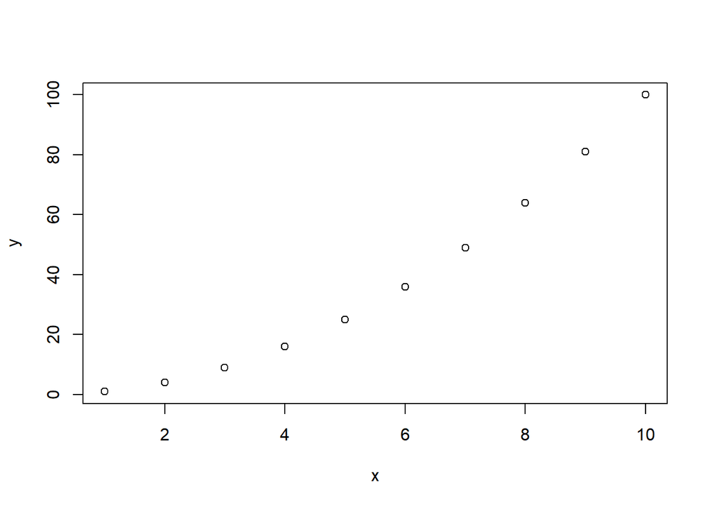

```r
x<-1:10
y<-x^2
plot(x,y)
```

**2. Ingresar la matriz A en RStudio** $A = \begin{pmatrix} 1 & 2 & 3 \\ 2 & 4 & 6 \\ 3 & 6 & 9 \\ 4 & 8 & 12 \end{pmatrix}$

```r
a1 <- seq(1,3)
a2 <- seq(2,6,2)
a3 <- seq(3,9,3)
a4 <- seq(4,12,4)
matrix_A<- rbind(a1,a2,a3,a4)
matrix_A
```

```
##    [,1] [,2] [,3]
## a1    1    2    3
## a2    2    4    6
## a3    3    6    9
## a4    4    8   12
```

**3. Ingresar la matriz identidad de tamaño 3** $I = \begin{pmatrix} 1 & 0 & 0 \\ 0 & 1 & 0 \\ 0 & 0 & 1 \end{pmatrix}$

```r
I <- diag(3)
I
```

```
##      [,1] [,2] [,3]
## [1,]    1    0    0
## [2,]    0    1    0
## [3,]    0    0    1
```

```r
matrix_nula <- function(r,c){
  return(diag(,r,c));
}
matrix_nula(8,8)
```

```
##      [,1] [,2] [,3] [,4] [,5] [,6] [,7] [,8]
## [1,]    1    0    0    0    0    0    0    0
## [2,]    0    1    0    0    0    0    0    0
## [3,]    0    0    1    0    0    0    0    0
## [4,]    0    0    0    1    0    0    0    0
## [5,]    0    0    0    0    1    0    0    0
## [6,]    0    0    0    0    0    1    0    0
## [7,]    0    0    0    0    0    0    1    0
## [8,]    0    0    0    0    0    0    0    1
```

**5. Modificar la matriz `diag(4)`, para que se parezca a la matriz B** $B = \begin{pmatrix} 0 & 0 & 0 & 0 \\ 0 & 2 & 0 & 0 \\ 0 & 0 & 3 & 0 \\ 0 & 0 & 0 & 4 \end{pmatrix}$

```r
matrix_B <- diag(4)
matrix_B[1,1] <- 0
matrix_B[2,2] <- 2
matrix_B[3,3] <- 3
matrix_B[4,4] <- 4
matrix_B
```

```
##      [,1] [,2] [,3] [,4]
## [1,]    0    0    0    0
## [2,]    0    2    0    0
## [3,]    0    0    3    0
## [4,]    0    0    0    4
```

**6. Obtener la matriz transpuesta de A (ejercicio 2)**

```r
trans_A <- t(matrix_A)
trans_A
```

```
##      a1 a2 a3 a4
## [1,]  1  2  3  4
## [2,]  2  4  6  8
## [3,]  3  6  9 12
```

**7. Realizar las siguientes operaciones $A + B$, $A - B$, $3B$ y $AB$**

```r
#c. 3B
3*matrix_B
```

```
##      [,1] [,2] [,3] [,4]
## [1,]    0    0    0    0
## [2,]    0    6    0    0
## [3,]    0    0    9    0
## [4,]    0    0    0   12
```

**8. Crea una función para calcular $P^6$** $P = \begin{pmatrix} 1 & 2 & 3 \\ -2 & 4 & -2 \\ 1 & 0 & 1 \end{pmatrix}$

```r
P <- rbind(c(1,2,3),c(-2,4,-2),c(1,0,1))

potencia_M <-function(M,n){
  Mi=M
  for(i in 2:n){
    Mi=Mi%*%M};
print(Mi)}

potencia_M(P,6)
```

```
##       [,1]  [,2]  [,3]
## [1,] -1792    24 -2824
## [2,]  -464 -2416 -1344
## [3,]  -648   440  -912
```

**9. Resolver el sistema de ecuaciones** $3x - y + z = -1\\9x - 2y + z = -9\\3x + y - 2z = -9$

```r
matrix_sist <- matrix(c(3,-1,1,9,-2,1,3,1,-2), nrow = 3, byrow= T)
matrix_sol <- c(-1,-9,-9)
solve(matrix_sist,matrix_sol)
```

```
## [1] -1  2  4
```

**10. Utilizando la ayuda de R, investigue para qué sirven las funciones `eigen()` y `det()`**

**11. Considerando las matrices**

B=
$$\begin{pmatrix}
1 & 2 & 3 & 4 & 5 \\
2 & 4 & 6 & 8 & 10 \\
3 & 6 & 9 & 12 & 15 \\
4 & 8 & 12 & 16 & 20 \\
5 & 10 & 15 & 20 & 25 \\
6 & 12 & 18 & 24 & 30 \\
7 & 14 & 21 & 28 & 35 \\
8 & 16 & 24 & 32 & 40 \\
9 & 18 & 27 & 36 & 45 \\
10 & 20 & 30 & 40 & 50
\end{pmatrix}$$
A =
$$\begin{pmatrix}
0 & 1 & 0 & 1 & 0 \\
1 & 0 & 1 & 0 & 1 \\
0 & 1 & 0 & 1 & 0 \\
0 & 1 & 0 & 0 & 1 \\
1 & 0 & 1 & 1 & 0 \\
\end{pmatrix}$$

```r
b1 <- seq(1,10)
b2 <- seq(2,20,2)
b3 <- seq(3,30,3)
b4 <- seq(4,40,4)
b5 <- seq(5,50,5)
B <- cbind(b1,b2,b3,b4,b5)

A <- matrix(c(0,1,0,1,0,1,0,1,0,1,0,1,0,1,0,0,1,0,0,1,1,0,1,1,0), nrow = 5, byrow = T)

#A %*% B # No se puede porque no tienen las mismas dimensiones
t_B <- t(B)
A %*% t_B #Resultado final !
```

```
##      [,1] [,2] [,3] [,4] [,5] [,6] [,7] [,8] [,9] [,10]
## [1,]    6   12   18   24   30   36   42   48   54    60
## [2,]    9   18   27   36   45   54   63   72   81    90
## [3,]    6   12   18   24   30   36   42   48   54    60
## [4,]    7   14   21   28   35   42   49   56   63    70
## [5,]    8   16   24   32   40   48   56   64   72    80
```

**12. Considere** $\hat\beta = (X^t \cdot X)^{-1} \cdot X^t \cdot Y$

Determine la matriz $\hat\beta$

x=
$$\begin{pmatrix}1 & 1\\ 1 & -1\\ 1 & 0\\ 1 & 1\\ 1 & 2\\ \end{pmatrix}$$
y =
$$\begin{pmatrix}0\\0\\1\\1\\3\\\end{pmatrix}$$

```r
X <- matrix(c(1,1,1,-1,1,0,1,1,1,2), ncol = 2, byrow = T)
Y <- matrix(c(0,0,1,1,3))
X_t <- t(X)

beta <- (solve(X_t %*% X) %*% X_t) %*% Y
beta
```

```
##           [,1]
## [1,] 0.5384615
## [2,] 0.7692308
```

**13. Corre el siguiente código para cargar los vectores `year` y `co2`** en memoria

```r
data(co2)
means = aggregate(co2, FUN=mean)
year = as.vector(time(means))
co2 = as.vector(means)
```

- El vector `co2` contiene medidas de $CO_2$ en la atmósfera, en unidades de *ppm*, durante el periodo 1959-1997. El vector `year` contiene sus años correspondientes.
- Calcular un vector de diferencias de $CO_2$ entre años consecutivos, que sería:
  - $CO_2$ en 1960 menos $CO_2$ en 1959
  - $CO_2$ en 1961 menos $CO_2$ en 1960
  - y así sucesivamente…
- Crear un **plot** con lineas y puntos mostrando las diferencias consecutivas de $CO_2$ en función del tiempo (1960, 1961, etc…), en **negrita**
- La diferencia de concentración de $CO_2$ entre 2020 y 2019 fue igual a 2.64. Agregar un punto rojo representando esa diferencia al plot ya creado (usar una forma diferente, como `pch=4`)

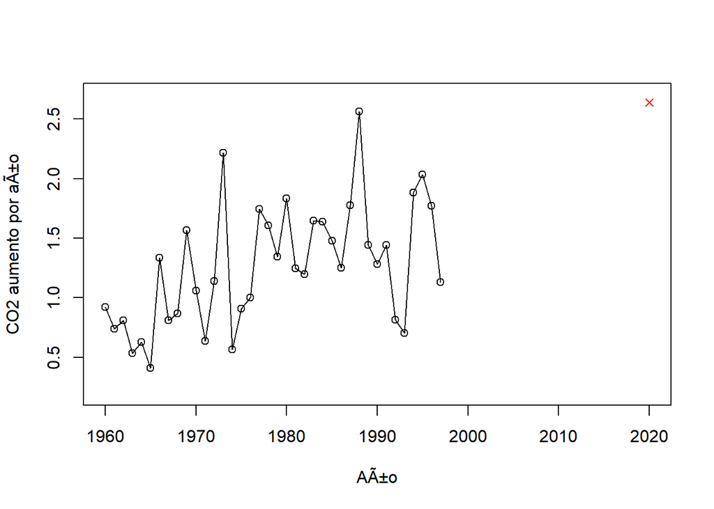

```r
data(co2)
means = aggregate(co2, FUN=mean)
year = as.vector(time(means))
co2 = as.vector(means)

dif <- co2 - dplyr::lag(co2)

dif_2020_2019 <- 2.64
year_2020 <- 2020

plot(x = year, y = dif,
     type = "o",
     xlab = "AÃ±o",
     ylab = "CO2 aumento por aÃ±o",
     xlim = c(1960, 2020),
     ylim = c(0.2, 2.7))
points(x = year_2020, y = dif_2020_2019, pch = 4, col = "red")
```

**14.** - Lee el archivo `rainfall.csv` como un `data.frame` - Calcula e imprime un vector con los nombres de las estaciones donde al menos uno de los meses tiene una precipitación superior a 180mm.

## Parte 3

**15. Manipule los dataframe según se solicite**

Se tiene el conjuntos de datos de precipitación diaria (período 1980 - 2013) de ciertas estaciones meteorológicas (**raingaugeDataset.csv**), donde cada una de estas están asociadas a un código único (**p.e. qc00000208**). Asimismo, se tiene una lista con los nombres, códigos, coordenadas y elevación de cada una de las estaciones (**listRaingauge.csv**).

A cada grupo le corresponde la siguiente estación:

- **Grupo 01**: MALLARES
- **Grupo 02**: TABACONAS
- **Grupo 03**: PUERTO PIZARRO
- **Grupo 04**: MORROPON
- **Grupo 05**: SAN MIGUEL
- **Grupo 06**: CHULUCANAS
- **Grupo 07**: LAMBAYEQUE
- **Grupo 08**: EL LIMON
- **Grupo 09**: EL SALTO
- **Grupo 10**: CHUSIS

De lo descrito anteriormente, se solicita:

1. Determine la cantidad de **missing values** de la serie de tiempo a paso diario.
2. Calcule la serie de tiempo de precipitación **acumulada mensual** (si el # de días con missing values, en un mes, supera el 10%, la precipitación acumulada mensual será considerado como un **`NA`**).
3. Determine la cantidad de **missing values** de la serie de tiempo a paso mensual.
4. Cree una función que calcule, a partir de los datos de preicpitación mensual, la **climatología (Ene-Dic)** para el **período 1980-2010**.
5. Poltear (boxplot) la variabilidad de los valores mensuales (Ene-Dic) para el período 1980-2013.